# Premier League Transfer Data

## 3. Exploratory Data Analysis

Now that we have our completely tidy datasets, it’s time to begin our analysis of the information throughout the datasets through manipulatory operations. We will perform this with some statistical measures and data visualization.

First let’s take a look at the mean and standard deviations!

```r
## mean
mean16 <- mean(df_2016$NetIncome)
mean17 <- mean(df_2017$NetIncome)
mean18 <- mean(df_2018$NetIncome)

mean16
```

```
## [1] -32.59
```

```r
mean17
```

```
## [1] -37.668
```

```r
mean18
```

```
## [1] -50.1565
```

Ok, so now we have the mean NET TRANSFER INCOME for the premier league from years 2016-2018 (in millions). What does this mean? The net transfer income indicates how much money a club made by just buying and selling players. From the data you can see that on average, each team significantly spent more money than they made through trading players, hence the negative values.

```r
std16 <- sd(df_2016$NetIncome)
std17 <- sd(df_2017$NetIncome)
std18 <- sd(df_2018$NetIncome)

std16
```

```
## [1] 44.57684
```

```r
std17
```

```
## [1] 54.3744
```

```r
std18
```

```
## [1] 41.1132
```

Comparing the standard deviation to the mean, you can see that the distribution of our NET TRANSFER INCOME is very spread out.

### 3.1 Data Transformation

```r
standardized16 <- df_2016 %>%
  mutate(mean_score = mean(df_2016$NetIncome)) %>%
  mutate(sd_aff = sd(df_2016$NetIncome)) %>%
  mutate(z_aff = (df_2016$NetIncome-mean_score) / sd_aff)
mean16_std <- mean(standardized16$z_aff)
mean16_std
```

```
## [1] 8.122978e-17
```

```r
standardized17 <- df_2017 %>%
  mutate(mean_score = mean(df_2017$NetIncome)) %>%
  mutate(sd_aff = sd(df_2017$NetIncome)) %>%
  mutate(z_aff = (df_2017$NetIncome-mean_score) / sd_aff)
mean17_std <- mean(standardized17$z_aff)
mean17_std
```

```
## [1] -2.009772e-17
```

```r
standardized18 <- df_2018 %>%
  mutate(mean_score = mean(df_2018$NetIncome)) %>%
  mutate(sd_aff = sd(df_2018$NetIncome)) %>%
  mutate(z_aff = (df_2018$NetIncome-mean_score) / sd_aff)
mean18_std <- mean(standardized18$z_aff)
mean18_std
```

```
## [1] -9.008365e-18
```

We standardize our data in order to be able to compare to points easier. Realistically, these values should be 0 but are close enough where we should not see any error coming from them.

### 3.2 Visualization R

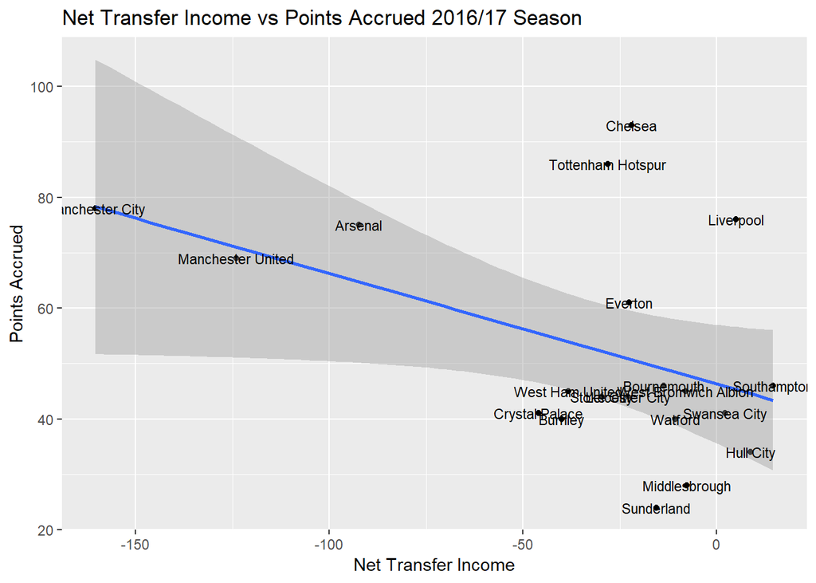

```r
df_2016 %>%
  ggplot(aes(x=NetIncome, y = Pts)) +
  geom_point() +
  geom_smooth(method=lm) +
  geom_text(aes(label = df_2016$'Team[ vte ]'), size = 3) +
  labs(title = "Net Transfer Income vs Points Accrued 2016/17 Season", x = "Net Transfer Income", y = "Points Accrued")
```

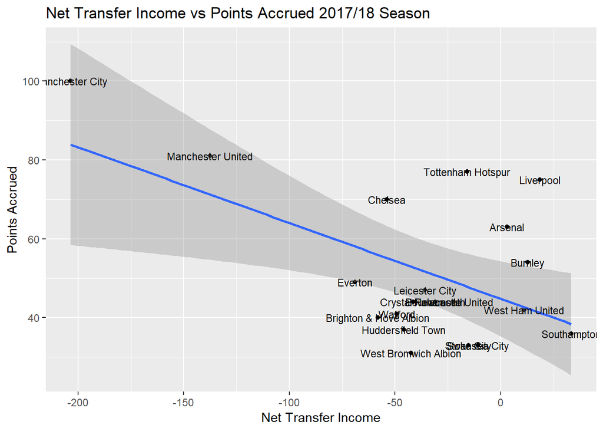

```r
df_2017 %>%
  ggplot(aes(x=NetIncome, y = Pts)) +
  geom_point() +
  geom_smooth(method=lm) +
  geom_text(aes(label = df_2017$'Team[ vte ]'), size = 3) +
  labs(title = "Net Transfer Income vs Points Accrued 2017/18 Season", x = "Net Transfer Income", y = "Points Accrued")
```

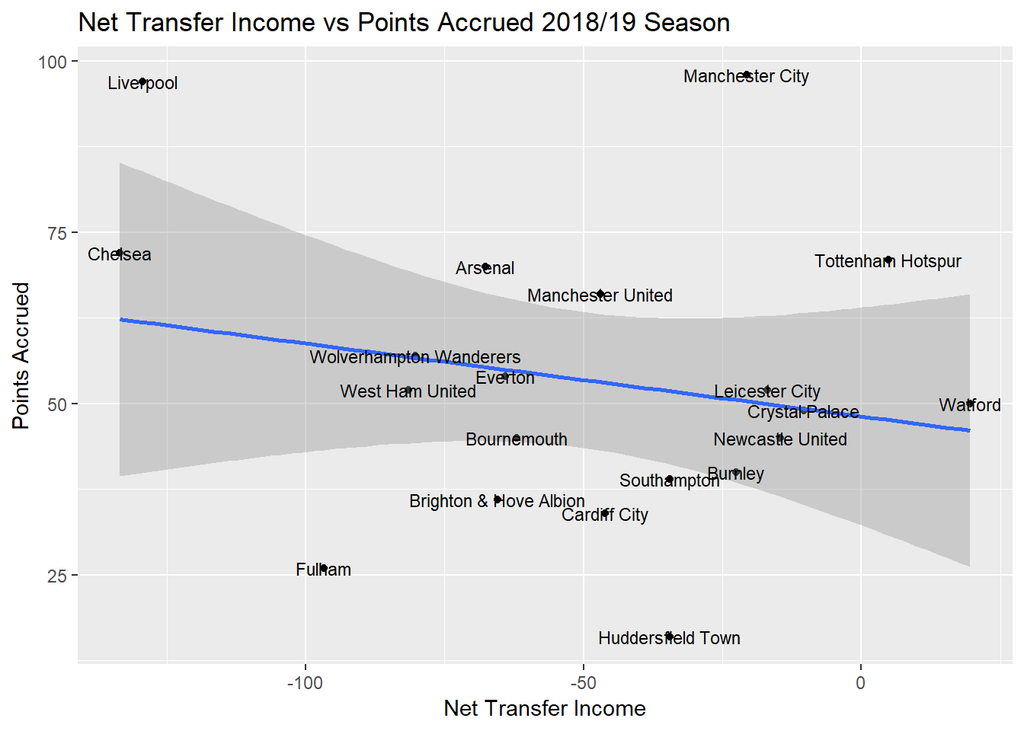

```r
df_2018 %>%
  ggplot(aes(x=NetIncome, y = Pts)) +
  geom_point() +
  geom_smooth(method=lm) +
  geom_text(aes(label = df_2018$'Team[ vte ]'), size = 3) +
  labs(title = "Net Transfer Income vs Points Accrued 2018/19 Season", x = "Net Transfer Income", y = "Points Accrued")
```

One of our larger questions and concerns for this data is how much does spending habits effect your points in the league. In the premier league a win rewards your team with 3 points, a tie with 1, and a loss with 0. This scoring system is used for a 38 game season. Looking into this, the team with the highest y-value (points accrued) won the league for that year. From the model you can see the negative trend of net income to points accrued, which makes sense. What is highly interesting is the fact the winning team for the league in 2016 and 2018 actually made more money in transfers than the mean for that year. While in 2017 Manchester City shows us that the more money you spend the more points you get.

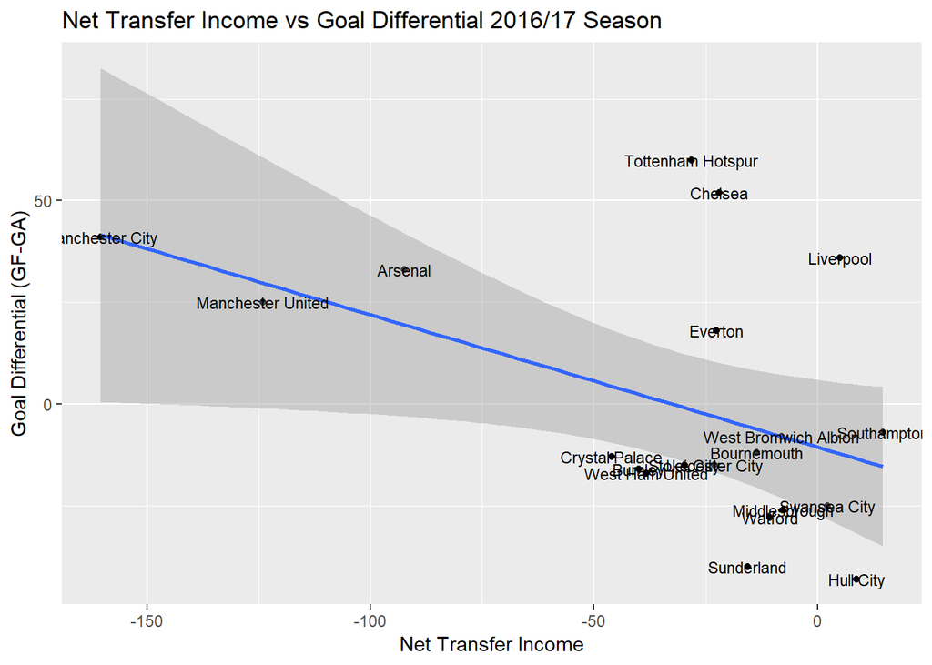

```r
df_2016 %>%
  ggplot(aes(x=NetIncome, y = GD)) +
  geom_point() +
  geom_smooth(method=lm) +
  geom_text(aes(label = df_2016$'Team[ vte ]'), size = 3) +
  labs(title = "Net Transfer Income vs Goal Differential 2016/17 Season", x = "Net Transfer Income", y = "Goal Differential (GF-GA)")
```

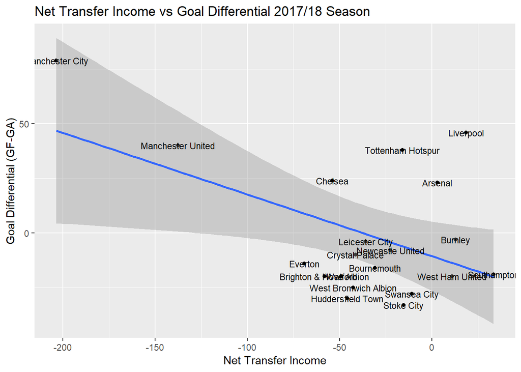

```r
df_2017 %>%
  ggplot(aes(x=NetIncome, y = GD)) +
  geom_point() +
  geom_smooth(method=lm) +
  geom_text(aes(label = df_2017$'Team[ vte ]'), size = 3) +
  labs(title = "Net Transfer Income vs Goal Differential 2017/18 Season", x = "Net Transfer Income", y = "Goal Differential (GF-GA)")
```

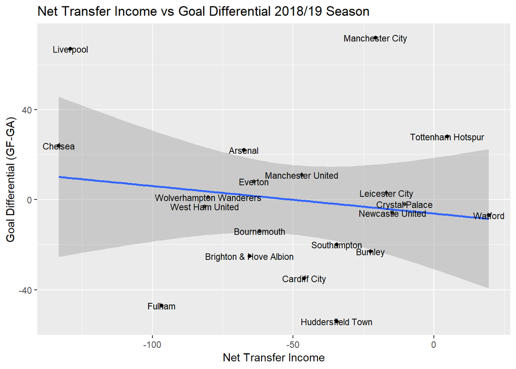

```r
df_2018 %>%
  ggplot(aes(x=NetIncome, y = GD)) +
  geom_point() +
  geom_smooth(method=lm) +
  geom_text(aes(label = df_2018$'Team[ vte ]'), size = 3) +
  labs(title = "Net Transfer Income vs Goal Differential 2018/19 Season", x = "Net Transfer Income", y = "Goal Differential (GF-GA)")
```

These linear regression models depict how correlated net transfer income is with goal differential. Goal differential is defined as the total amount of goals scored - total amount of goals allowed for the year. We expect a similar relationship with GD to net income as points to net income because you have to score more goals than allow in order to get more points. Again you can see a negative linear relationship in 2016 and 2017 and a weaker relationship in 2018. What next!

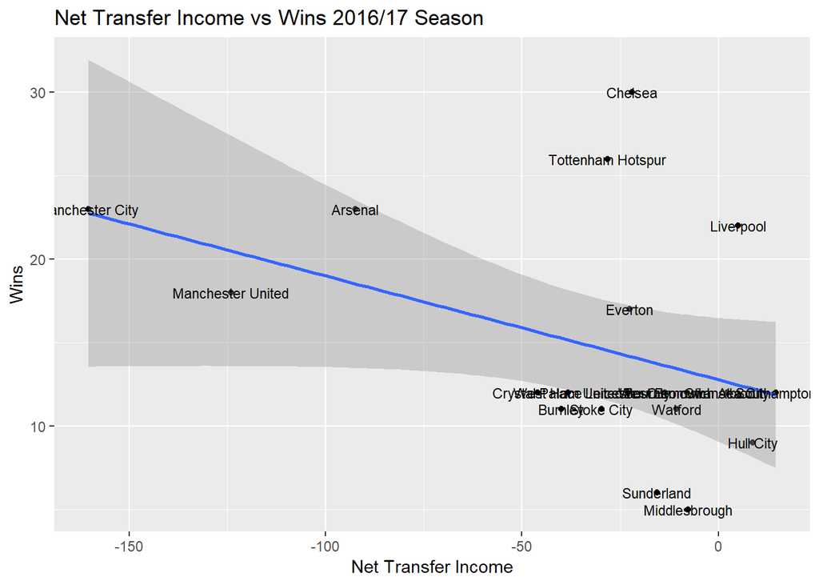

```r
df_2016 %>%
  ggplot(aes(x=NetIncome, y = W)) +
  geom_point() +
  geom_smooth(method=lm) +
  geom_text(aes(label = df_2016$'Team[ vte ]'), size = 3) +
  labs(title = "Net Transfer Income vs Wins 2016/17 Season", x = "Net Transfer Income", y = "Wins")
```

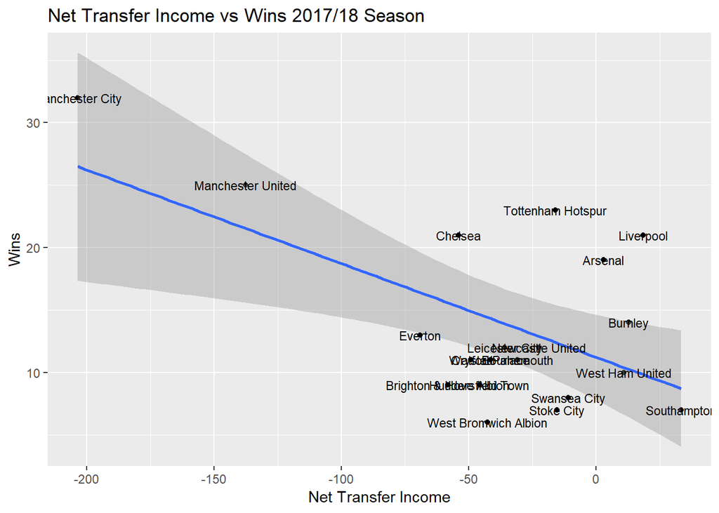

```r
df_2017 %>%
  ggplot(aes(x=NetIncome, y = W)) +
  geom_point() +
  geom_smooth(method=lm) +
  geom_text(aes(label = df_2017$'Team[ vte ]'), size = 3) +
  labs(title = "Net Transfer Income vs Wins 2017/18 Season", x = "Net Transfer Income", y = "Wins")
```